# ADA Final

Table 1 not stratified

```r
table1(~ sex+exercise_30days+annual_income+insurance+general_health,data = obesity_data_final)
```

|  | Overall (N=175925) |
| --- | --- |
| sex |  |
| Male | 84523 (48.0%) |
| Female | 91402 (52.0%) |
| exercise_30days |  |
| Yes | 151054 (85.9%) |
| No | 24871 (14.1%) |
| annual_income |  |
| Less than $15,000 | 5350 (3.0%) |
| $15,000 to < $25,000 | 11080 (6.3%) |
| $25,000 to < $35,000 | 17111 (9.7%) |
| $35,000 to < $50,000 | 22101 (12.6%) |
| $50,000 to < $100,000 | 60661 (34.5%) |
| $100,000 to < $200,000 | 45311 (25.8%) |
| $200,000 or more | 14311 (8.1%) |
| insurance |  |
| Yes | 167705 (95.3%) |
| No | 8220 (4.7%) |
| general_health |  |
| Good or Better Health | 59413 (33.8%) |
| Fair or Poor Health | 116512 (66.2%) |
| Don’t know/Missing | 0 (0%) |

Stratifying my Table 1 using general health status.

```r
#creating table 1 and data summary
table1(~ sex+exercise_30days+annual_income+insurance|general_health,data = obesity_data_final)
```

|  | Good or Better Health (N=59413) | Fair or Poor Health (N=116512) | Overall (N=175925) |
| --- | --- | --- | --- |
| sex |  |  |  |
| Male | 29738 (50.1%) | 54785 (47.0%) | 84523 (48.0%) |
| Female | 29675 (49.9%) | 61727 (53.0%) | 91402 (52.0%) |
| exercise_30days |  |  |  |
| Yes | 52378 (88.2%) | 98676 (84.7%) | 151054 (85.9%) |
| No | 7035 (11.8%) | 17836 (15.3%) | 24871 (14.1%) |
| annual_income |  |  |  |
| Less than $15,000 | 1954 (3.3%) | 3396 (2.9%) | 5350 (3.0%) |
| $15,000 to < $25,000 | 3662 (6.2%) | 7418 (6.4%) | 11080 (6.3%) |
| $25,000 to < $35,000 | 5404 (9.1%) | 11707 (10.0%) | 17111 (9.7%) |
| $35,000 to < $50,000 | 6669 (11.2%) | 15432 (13.2%) | 22101 (12.6%) |
| $50,000 to < $100,000 | 19271 (32.4%) | 41390 (35.5%) | 60661 (34.5%) |
| $100,000 to < $200,000 | 16084 (27.1%) | 29227 (25.1%) | 45311 (25.8%) |
| $200,000 or more | 6369 (10.7%) | 7942 (6.8%) | 14311 (8.1%) |
| insurance |  |  |  |
| Yes | 55928 (94.1%) | 111777 (95.9%) | 167705 (95.3%) |
| No | 3485 (5.9%) | 4735 (4.1%) | 8220 (4.7%) |

Interpretations This table provides a comprehensive overview of general health status, exercise habits, income levels, and insurance coverage among individuals.

Among them, 59,413 reported having “Good or Better Health, while 116,512 indicated”Fair or Poor Health.

Notably, females comprised a slightly larger portion of the sample at 52.0%, compared to males at 48.0%.

Regarding exercise in the last 30 days, a significant majority of individuals (85.8%) engaged in physical activity, with only 14.2% not exercising.

When looking at income levels, it turns out that those earning between $50,000 and $100,000 represented the largest group at 34.5%, while only 3.0% reported an income of less than $15,000.

This comprehensive analysis underscores the interconnection of gender, exercise, income, and insurance in relation to health outcomes.

stratified by insurance

```r
table1(~ sex+exercise_30days+annual_income+general_health|insurance,data = obesity_data_final)
```

|  | Yes (N=167705) | No (N=8220) | Overall (N=175925) |
| --- | --- | --- | --- |
| sex |  |  |  |
| Male | 79599 (47.5%) | 4924 (59.9%) | 84523 (48.0%) |
| Female | 88106 (52.5%) | 3296 (40.1%) | 91402 (52.0%) |
| exercise_30days |  |  |  |
| Yes | 144561 (86.2%) | 6493 (79.0%) | 151054 (85.9%) |
| No | 23144 (13.8%) | 1727 (21.0%) | 24871 (14.1%) |
| annual_income |  |  |  |
| Less than $15,000 | 4596 (2.7%) | 754 (9.2%) | 5350 (3.0%) |
| $15,000 to < $25,000 | 9754 (5.8%) | 1326 (16.1%) | 11080 (6.3%) |
| $25,000 to < $35,000 | 15385 (9.2%) | 1726 (21.0%) | 17111 (9.7%) |
| $35,000 to < $50,000 | 20586 (12.3%) | 1515 (18.4%) | 22101 (12.6%) |
| $50,000 to < $100,000 | 58595 (34.9%) | 2066 (25.1%) | 60661 (34.5%) |
| $100,000 to < $200,000 | 44649 (26.6%) | 662 (8.1%) | 45311 (25.8%) |
| $200,000 or more | 14140 (8.4%) | 171 (2.1%) | 14311 (8.1%) |
| general_health |  |  |  |
| Good or Better Health | 55928 (33.3%) | 3485 (42.4%) | 59413 (33.8%) |
| Fair or Poor Health | 111777 (66.7%) | 4735 (57.6%) | 116512 (66.2%) |
| Don’t know/Missing | 0 (0%) | 0 (0%) | 0 (0%) |

lets do some visualizations to help my model

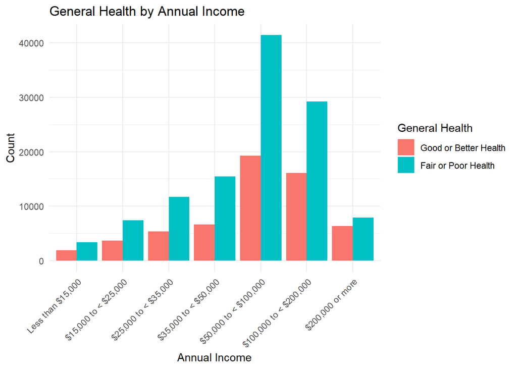

```r
# Bar plot: General health by annual income
ggplot(obesity_data_final, aes(x = annual_income, fill = general_health)) +
  geom_bar(position = "dodge") +
  labs(title = "General Health by Annual Income", x = "Annual Income", y = "Count", fill = "General Health") +
  theme_minimal() +
  theme(axis.text.x = element_text(angle = 45, hjust = 1))
```

For instance, the income range of $100,000 to < $200,000 shows a significant number of people in good health, while those earning less than $15,000 have fewer individuals reporting good health.

checking out a forest plot

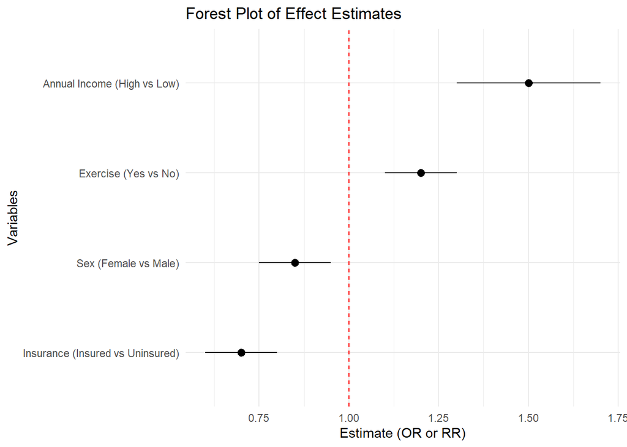

```r
# Sample data without the "General Health" outcome
forest_data <- data.frame(
  variable = c("Sex (Female vs Male)", "Exercise (Yes vs No)", "Annual Income (High vs Low)", "Insurance (Insured vs Uninsured)"),
  estimate = c(0.85, 1.2, 1.5, 0.7),
  ci_lower = c(0.75, 1.1, 1.3, 0.6),
  ci_upper = c(0.95, 1.3, 1.7, 0.8)
)

# Load necessary package
library(ggplot2)

# Create forest plot
ggplot(forest_data, aes(x = reorder(variable, estimate), y = estimate, ymin = ci_lower, ymax = ci_upper)) +
  geom_pointrange() +
  geom_hline(yintercept = 1, linetype = "dashed", color = "red") + # Reference line at OR = 1
  coord_flip() + # Flip coordinates for horizontal plot
  labs(title = "Forest Plot of Effect Estimates",
       x = "Variables",
       y = "Estimate (OR or RR)") +
  theme_minimal()
```

This emphasizes the importance of socioeconomic and lifestyle factors in determining health.

fit a model

```r
ob_model <- glm(general_health ~ exercise_30days+annual_income+insurance +sex, data = obesity_data_final, family = binomial)
family = binomial(link = "logit")
```

checking the distributions

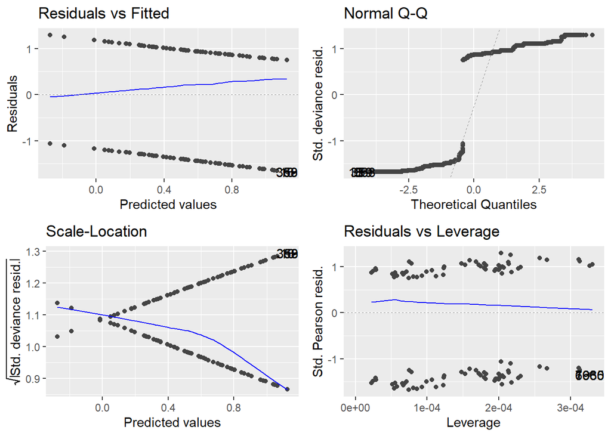

```r
autoplot(ob_model)
```

Lets check summary

```r
summary(ob_model)
```

```
##
## Call:
## glm(formula = general_health ~ exercise_30days + annual_income +
##     insurance + sex, family = binomial, data = obesity_data_final)
##
## Coefficients:
##                                     Estimate Std. Error z value Pr(>|z|)
## (Intercept)                          0.50018    0.02966  16.863  < 2e-16 ***
## exercise_30daysNo                    0.26052    0.01537  16.954  < 2e-16 ***
## annual_income$15,000 to < $25,000    0.14564    0.03501   4.160 3.18e-05 ***
## annual_income$25,000 to < $35,000    0.21872    0.03299   6.631 3.34e-11 ***
## annual_income$35,000 to < $50,000    0.27854    0.03217   8.659  < 2e-16 ***
## annual_income$50,000 to < $100,000   0.20307    0.03004   6.761 1.37e-11 ***
## annual_income$100,000 to < $200,000  0.04210    0.03049   1.381    0.167
## annual_income$200,000 or more       -0.32392    0.03348  -9.675  < 2e-16 ***
## insuranceNo                         -0.44929    0.02346 -19.151  < 2e-16 ***
## sexFemale                            0.08537    0.01020   8.368  < 2e-16 ***
## ---
## Signif. codes:  0 '***' 0.001 '**' 0.01 '*' 0.05 '.' 0.1 ' ' 1
##
## (Dispersion parameter for binomial family taken to be 1)
##
##     Null deviance: 225012  on 175924  degrees of freedom
## Residual deviance: 223206  on 175915  degrees of freedom
## AIC: 223226
##
## Number of Fisher Scoring iterations: 4
```

fiting my model using broom tidy to get estimates

```r
broom::tidy(ob_model, exponentiate = TRUE, conf.int = TRUE)
```

```
## # A tibble: 10 × 7
##    term                 estimate std.error statistic  p.value conf.low conf.high
##    <chr>                   <dbl>     <dbl>     <dbl>    <dbl>    <dbl>     <dbl>
##  1 (Intercept)             1.65     0.0297     16.9  8.41e-64    1.56      1.75
##  2 exercise_30daysNo       1.30     0.0154     17.0  1.78e-64    1.26      1.34
##  3 annual_income$15,00…    1.16     0.0350      4.16 3.18e- 5    1.08      1.24
##  4 annual_income$25,00…    1.24     0.0330      6.63 3.34e-11    1.17      1.33
##  5 annual_income$35,00…    1.32     0.0322      8.66 4.77e-18    1.24      1.41
##  6 annual_income$50,00…    1.23     0.0300      6.76 1.37e-11    1.15      1.30
##  7 annual_income$100,0…    1.04     0.0305      1.38 1.67e- 1    0.982     1.11
##  8 annual_income$200,0…    0.723    0.0335     -9.68 3.84e-22    0.677     0.772
##  9 insuranceNo             0.638    0.0235    -19.2  9.46e-82    0.609     0.668
## 10 sexFemale               1.09     0.0102      8.37 5.84e-17    1.07      1.11
```

Income also matters a lot. People who earn between $35,000 and $50,000 had noticeably worse outcomes, with a value 1.32 times higher than those who make less than $15,000(0R=1.32 ;95% CI 1.24,1.40)at P=0.05.

Lastly, females had slightly higher values (1.09 times) than males, but the difference wasn’t as big as the other factors(0R=1.09;95% CI 1.06,1.11)at P=0.05.

Overall, income, exercise, and insurance coverage seem to make the biggest difference in people’s health outcome.

checking for colinearity

```r
car::vif(ob_model)
```

```
##                     GVIF Df GVIF^(1/(2*Df))
## exercise_30days 1.031032  1        1.015398
## annual_income   1.075185  6        1.006059
## insurance       1.041884  1        1.020727
## sex             1.012776  1        1.006368
```

I can say that based on my the GVIF values the predictors do not strongly correlate with each other, and their inclusion in the model is unlikely to distort coefficient estimates. The model is stable, and the regression results may be interpreted with confidence.

```r
# Remove rows with missing values in the dataset
clean_data <- na.omit(obesity_data_final)

# Fit the full model using the cleaned dataset
full_model <- glm(general_health ~ sex + exercise_30days + annual_income + insurance,
                  data = clean_data, family = binomial)

# Fit the reduced model using the same cleaned dataset
reduced_model <- glm(general_health ~ sex + exercise_30days + insurance,
                     data = clean_data, family = binomial)

# Perform the Likelihood Ratio Test
library(lmtest)
lrt <- lrtest(full_model, reduced_model)
print(lrt)
```

```
## Likelihood ratio test
##
## Model 1: general_health ~ sex + exercise_30days + annual_income + insurance
## Model 2: general_health ~ sex + exercise_30days + insurance
##   #Df  LogLik Df  Chisq Pr(>Chisq)
## 1  10 -111603
## 2   4 -112097 -6 987.32  < 2.2e-16 ***
## ---
## Signif. codes:  0 '***' 0.001 '**' 0.01 '*' 0.05 '.' 0.1 ' ' 1
```

I went ahead to do the likelihood ratio test to compare the two nested models assessing factors influencing general health.

The full model included all variables, while the reduced model excluded annual income.

The test yielded a highly significant result (Chi-square = 987.32, p < 2.2e-16), indicating that the inclusion of annual income significantly improved the model’s fit.

More so, the log-likelihood for the full model (-111603) was higher (less negative) than that of the reduced model (-112097), demonstrating that annual income provides critical explanatory power in predicting general health.

This result underscores the importance of income as a key determinant of health outcomes and suggests it should be retained in models evaluating health disparities.